# Risk Factor Analysis

## Outcome Variable

**Outcome Variable:** y_rate_haz

## Predictor Variables

**Intervention Variable:** predfeed3

**Adjustment Set:**

- arm
- sex
- month
- brthmon
- W_mage
- meducyrs
- feducyrs
- hhwealth_quart
- hfoodsec
- W_mhtcm
- W_mwtkg
- W_mbmi
- vagbrth
- W_gagebrth
- W_birthwt
- W_birthlen
- W_nrooms
- W_nchldlt5
- W_parity
- impfloor
- impsan
- safeh20
- delta_W_mage
- delta_meducyrs
- delta_feducyrs
- delta_hhwealth_quart
- delta_hfoodsec
- delta_W_mhtcm
- delta_W_mwtkg
- delta_W_mbmi
- delta_vagbrth
- delta_W_gagebrth
- delta_W_birthwt
- delta_W_birthlen
- delta_W_nrooms
- delta_W_nchldlt5
- delta_W_parity
- delta_impfloor
- delta_impsan
- delta_safeh20

## Stratifying Variables

The analysis was stratified on these variable(s):

- agecat
- studyid
- country

## Data Summary

| agecat | studyid | country | predfeed3 | n_cell | n |
| --- | --- | --- | --- | --- | --- |
| 0-3 months | EE | PAKISTAN | 1 | 31 | 31 |
| 0-3 months | EE | PAKISTAN | 0 | 0 | 31 |
| 0-3 months | GMS-Nepal | NEPAL | 1 | 378 | 456 |
| 0-3 months | GMS-Nepal | NEPAL | 0 | 78 | 456 |
| 0-3 months | JiVitA-3 | BANGLADESH | 1 | 10705 | 11852 |
| 0-3 months | JiVitA-3 | BANGLADESH | 0 | 1147 | 11852 |
| 0-3 months | JiVitA-4 | BANGLADESH | 1 | 111 | 121 |
| 0-3 months | JiVitA-4 | BANGLADESH | 0 | 10 | 121 |
| 0-3 months | MAL-ED | BANGLADESH | 1 | 193 | 237 |
| 0-3 months | MAL-ED | BANGLADESH | 0 | 44 | 237 |
| 0-3 months | MAL-ED | BRAZIL | 1 | 73 | 147 |
| 0-3 months | MAL-ED | BRAZIL | 0 | 74 | 147 |
| 0-3 months | MAL-ED | INDIA | 1 | 113 | 164 |
| 0-3 months | MAL-ED | INDIA | 0 | 51 | 164 |
| 0-3 months | MAL-ED | NEPAL | 1 | 81 | 153 |
| 0-3 months | MAL-ED | NEPAL | 0 | 72 | 153 |
| 0-3 months | MAL-ED | PERU | 1 | 168 | 262 |
| 0-3 months | MAL-ED | PERU | 0 | 94 | 262 |
| 0-3 months | MAL-ED | SOUTH AFRICA | 1 | 58 | 203 |
| 0-3 months | MAL-ED | SOUTH AFRICA | 0 | 145 | 203 |
| 0-3 months | MAL-ED | TANZANIA, UNITED REPUBLIC OF | 1 | 57 | 197 |
| 0-3 months | MAL-ED | TANZANIA, UNITED REPUBLIC OF | 0 | 140 | 197 |
| 3-6 months | EE | PAKISTAN | 1 | 31 | 31 |
| 3-6 months | EE | PAKISTAN | 0 | 0 | 31 |
| 3-6 months | GMS-Nepal | NEPAL | 1 | 350 | 420 |
| 3-6 months | GMS-Nepal | NEPAL | 0 | 70 | 420 |
| 3-6 months | JiVitA-3 | BANGLADESH | 1 | 6478 | 7103 |
| 3-6 months | JiVitA-3 | BANGLADESH | 0 | 625 | 7103 |
| 3-6 months | JiVitA-4 | BANGLADESH | 1 | 21 | 21 |
| 3-6 months | JiVitA-4 | BANGLADESH | 0 | 0 | 21 |

[output cut: 130 more lines]

The following strata were considered:

- agecat: 0-3 months, studyid: EE, country: PAKISTAN
- agecat: 0-3 months, studyid: GMS-Nepal, country: NEPAL
- agecat: 0-3 months, studyid: JiVitA-3, country: BANGLADESH
- agecat: 0-3 months, studyid: JiVitA-4, country: BANGLADESH
- agecat: 0-3 months, studyid: MAL-ED, country: BANGLADESH
- agecat: 0-3 months, studyid: MAL-ED, country: BRAZIL
- agecat: 0-3 months, studyid: MAL-ED, country: INDIA
- agecat: 0-3 months, studyid: MAL-ED, country: NEPAL
- agecat: 0-3 months, studyid: MAL-ED, country: PERU
- agecat: 0-3 months, studyid: MAL-ED, country: SOUTH AFRICA
- agecat: 0-3 months, studyid: MAL-ED, country: TANZANIA, UNITED REPUBLIC OF
- agecat: 12-15 months, studyid: EE, country: PAKISTAN
- agecat: 12-15 months, studyid: GMS-Nepal, country: NEPAL
- agecat: 12-15 months, studyid: JiVitA-4, country: BANGLADESH
- agecat: 12-15 months, studyid: MAL-ED, country: BANGLADESH
- agecat: 12-15 months, studyid: MAL-ED, country: BRAZIL
- agecat: 12-15 months, studyid: MAL-ED, country: INDIA
- agecat: 12-15 months, studyid: MAL-ED, country: NEPAL
- agecat: 12-15 months, studyid: MAL-ED, country: PERU
- agecat: 12-15 months, studyid: MAL-ED, country: SOUTH AFRICA
- agecat: 12-15 months, studyid: MAL-ED, country: TANZANIA, UNITED REPUBLIC OF
- agecat: 15-18 months, studyid: EE, country: PAKISTAN
- agecat: 15-18 months, studyid: GMS-Nepal, country: NEPAL
- agecat: 15-18 months, studyid: JiVitA-4, country: BANGLADESH
- agecat: 15-18 months, studyid: MAL-ED, country: BANGLADESH
- agecat: 15-18 months, studyid: MAL-ED, country: BRAZIL
- agecat: 15-18 months, studyid: MAL-ED, country: INDIA
- agecat: 15-18 months, studyid: MAL-ED, country: NEPAL
- agecat: 15-18 months, studyid: MAL-ED, country: PERU
- agecat: 15-18 months, studyid: MAL-ED, country: SOUTH AFRICA
- agecat: 15-18 months, studyid: MAL-ED, country: TANZANIA, UNITED REPUBLIC OF
- agecat: 18-21 months, studyid: EE, country: PAKISTAN
- agecat: 18-21 months, studyid: GMS-Nepal, country: NEPAL
- agecat: 18-21 months, studyid: MAL-ED, country: BANGLADESH
- agecat: 18-21 months, studyid: MAL-ED, country: BRAZIL
- agecat: 18-21 months, studyid: MAL-ED, country: INDIA
- agecat: 18-21 months, studyid: MAL-ED, country: NEPAL
- agecat: 18-21 months, studyid: MAL-ED, country: PERU
- agecat: 18-21 months, studyid: MAL-ED, country: SOUTH AFRICA
- agecat: 18-21 months, studyid: MAL-ED, country: TANZANIA, UNITED REPUBLIC OF
- agecat: 21-24 months, studyid: EE, country: PAKISTAN
- agecat: 21-24 months, studyid: GMS-Nepal, country: NEPAL
- agecat: 21-24 months, studyid: MAL-ED, country: BANGLADESH
- agecat: 21-24 months, studyid: MAL-ED, country: BRAZIL
- agecat: 21-24 months, studyid: MAL-ED, country: INDIA
- agecat: 21-24 months, studyid: MAL-ED, country: NEPAL
- agecat: 21-24 months, studyid: MAL-ED, country: PERU
- agecat: 21-24 months, studyid: MAL-ED, country: SOUTH AFRICA
- agecat: 21-24 months, studyid: MAL-ED, country: TANZANIA, UNITED REPUBLIC OF
- agecat: 3-6 months, studyid: EE, country: PAKISTAN
- agecat: 3-6 months, studyid: GMS-Nepal, country: NEPAL
- agecat: 3-6 months, studyid: JiVitA-3, country: BANGLADESH
- agecat: 3-6 months, studyid: JiVitA-4, country: BANGLADESH
- agecat: 3-6 months, studyid: MAL-ED, country: BANGLADESH
- agecat: 3-6 months, studyid: MAL-ED, country: BRAZIL
- agecat: 3-6 months, studyid: MAL-ED, country: INDIA
- agecat: 3-6 months, studyid: MAL-ED, country: NEPAL
- agecat: 3-6 months, studyid: MAL-ED, country: PERU
- agecat: 3-6 months, studyid: MAL-ED, country: SOUTH AFRICA
- agecat: 3-6 months, studyid: MAL-ED, country: TANZANIA, UNITED REPUBLIC OF
- agecat: 6-9 months, studyid: EE, country: PAKISTAN
- agecat: 6-9 months, studyid: GMS-Nepal, country: NEPAL
- agecat: 6-9 months, studyid: JiVitA-4, country: BANGLADESH
- agecat: 6-9 months, studyid: MAL-ED, country: BANGLADESH
- agecat: 6-9 months, studyid: MAL-ED, country: BRAZIL
- agecat: 6-9 months, studyid: MAL-ED, country: INDIA
- agecat: 6-9 months, studyid: MAL-ED, country: NEPAL
- agecat: 6-9 months, studyid: MAL-ED, country: PERU
- agecat: 6-9 months, studyid: MAL-ED, country: SOUTH AFRICA
- agecat: 6-9 months, studyid: MAL-ED, country: TANZANIA, UNITED REPUBLIC OF
- agecat: 9-12 months, studyid: EE, country: PAKISTAN
- agecat: 9-12 months, studyid: GMS-Nepal, country: NEPAL
- agecat: 9-12 months, studyid: JiVitA-4, country: BANGLADESH
- agecat: 9-12 months, studyid: MAL-ED, country: BANGLADESH
- agecat: 9-12 months, studyid: MAL-ED, country: BRAZIL
- agecat: 9-12 months, studyid: MAL-ED, country: INDIA
- agecat: 9-12 months, studyid: MAL-ED, country: NEPAL
- agecat: 9-12 months, studyid: MAL-ED, country: PERU
- agecat: 9-12 months, studyid: MAL-ED, country: SOUTH AFRICA
- agecat: 9-12 months, studyid: MAL-ED, country: TANZANIA, UNITED REPUBLIC OF

### Dropped Strata

Some strata were dropped due to rare outcomes:

- agecat: 0-3 months, studyid: EE, country: PAKISTAN
- agecat: 3-6 months, studyid: EE, country: PAKISTAN
- agecat: 3-6 months, studyid: JiVitA-4, country: BANGLADESH
- agecat: 6-9 months, studyid: EE, country: PAKISTAN
- agecat: 6-9 months, studyid: JiVitA-4, country: BANGLADESH
- agecat: 9-12 months, studyid: EE, country: PAKISTAN
- agecat: 12-15 months, studyid: EE, country: PAKISTAN
- agecat: 15-18 months, studyid: EE, country: PAKISTAN
- agecat: 18-21 months, studyid: EE, country: PAKISTAN
- agecat: 21-24 months, studyid: EE, country: PAKISTAN

## Methods Detail

We’re interested in the causal parameters $E[Y_a]$ for all values of $a \in \mathcal{A}$. These parameters represent the mean outcome if, possibly contrary to fact, we intervened to set all units to have $A=a$. Under the randomization and positivity assumptions, these are identified by the statistical parameters $\psi_a=E_W[E_{Y|A,W}(Y|A=a,W)]$. In addition, we’re interested in the mean of $Y$, $E[Y]$ under no intervention (the observed mean). We will estimate these parameters by using SuperLearner to fit the relevant likelihood factors – $E_{Y|A,W}(Y|A=a,W)$ and $p(A=a|W)$, and then updating our likelihood fit using a joint TMLE.

For unadjusted analyses ($W=\{\}$), initial likelihoods were estimated using Lrnr_glm to estimate the simple $E(Y|A)$ and Lrnr_mean to estimate $p(A)$. For adjusted analyses, a small library containing Lrnr_glmnet, Lrnr_xgboost, and Lrnr_mean was used.

Having estimated these parameters, we will then use the delta method to estimate relative risks and attributable risks relative to a prespecified baseline level of $A$.

# Results Detail

## Results Plots

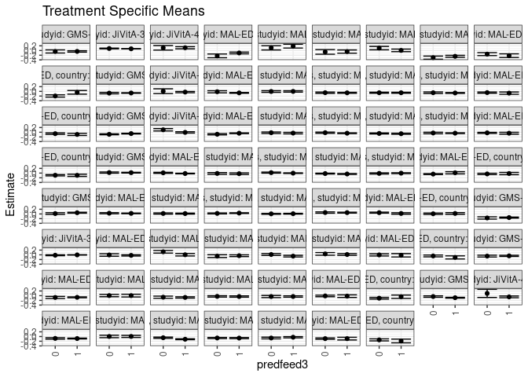

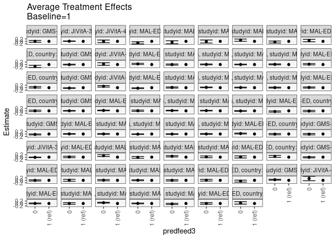

[figure not shown]

## Results Table

### Parameter: TSM

| agecat | studyid | country | intervention_level | baseline_level | estimate | ci_lower | ci_upper |
| --- | --- | --- | --- | --- | --- | --- | --- |
| 0-3 months | GMS-Nepal | NEPAL | 1 | NA | -0.0380514 | -0.0671050 | -0.0089978 |
| 0-3 months | GMS-Nepal | NEPAL | 0 | NA | -0.0397200 | -0.1064221 | 0.0269821 |
| 0-3 months | JiVitA-3 | BANGLADESH | 1 | NA | 0.0735648 | 0.0671725 | 0.0799571 |
| 0-3 months | JiVitA-3 | BANGLADESH | 0 | NA | 0.0862677 | 0.0698424 | 0.1026930 |
| 0-3 months | JiVitA-4 | BANGLADESH | 1 | NA | 0.1172967 | 0.0708731 | 0.1637204 |
| 0-3 months | JiVitA-4 | BANGLADESH | 0 | NA | 0.1150364 | 0.0184670 | 0.2116058 |
| 0-3 months | MAL-ED | BANGLADESH | 1 | NA | -0.1034981 | -0.1408056 | -0.0661906 |
| 0-3 months | MAL-ED | BANGLADESH | 0 | NA | -0.2280983 | -0.3075544 | -0.1486421 |
| 0-3 months | MAL-ED | BRAZIL | 1 | NA | 0.1869188 | 0.1048673 | 0.2689702 |
| 0-3 months | MAL-ED | BRAZIL | 0 | NA | 0.1140371 | 0.0242019 | 0.2038723 |
| 0-3 months | MAL-ED | INDIA | 1 | NA | -0.0446623 | -0.1137018 | 0.0243773 |
| 0-3 months | MAL-ED | INDIA | 0 | NA | -0.0600806 | -0.1582395 | 0.0380783 |
| 0-3 months | MAL-ED | NEPAL | 1 | NA | 0.0063430 | -0.0487457 | 0.0614316 |
| 0-3 months | MAL-ED | NEPAL | 0 | NA | 0.1033549 | 0.0307431 | 0.1759666 |
| 0-3 months | MAL-ED | PERU | 1 | NA | -0.2474056 | -0.2895085 | -0.2053027 |
| 0-3 months | MAL-ED | PERU | 0 | NA | -0.3034274 | -0.3696847 | -0.2371702 |
| 0-3 months | MAL-ED | SOUTH AFRICA | 1 | NA | -0.2189586 | -0.2953154 | -0.1426018 |
| 0-3 months | MAL-ED | SOUTH AFRICA | 0 | NA | -0.1533166 | -0.2160675 | -0.0905657 |
| 0-3 months | MAL-ED | TANZANIA, UNITED REPUBLIC OF | 1 | NA | -0.0400508 | -0.1179154 | 0.0378138 |
| 0-3 months | MAL-ED | TANZANIA, UNITED REPUBLIC OF | 0 | NA | -0.1963831 | -0.2445160 | -0.1482501 |
| 3-6 months | GMS-Nepal | NEPAL | 1 | NA | -0.1547761 | -0.1762252 | -0.1333269 |
| 3-6 months | GMS-Nepal | NEPAL | 0 | NA | -0.1709786 | -0.2196594 | -0.1222978 |
| 3-6 months | JiVitA-3 | BANGLADESH | 1 | NA | -0.0038310 | -0.0103852 | 0.0027231 |
| 3-6 months | JiVitA-3 | BANGLADESH | 0 | NA | -0.0179831 | -0.0375705 | 0.0016044 |
| 3-6 months | MAL-ED | BANGLADESH | 1 | NA | -0.0240579 | -0.0503839 | 0.0022682 |
| 3-6 months | MAL-ED | BANGLADESH | 0 | NA | -0.0061768 | -0.0593917 | 0.0470382 |
| 3-6 months | MAL-ED | BRAZIL | 1 | NA | 0.0032548 | -0.0493963 | 0.0559059 |
| 3-6 months | MAL-ED | BRAZIL | 0 | NA | 0.1288852 | 0.0728346 | 0.1849359 |
| 3-6 months | MAL-ED | INDIA | 1 | NA | -0.0377405 | -0.0754959 | 0.0000148 |
| 3-6 months | MAL-ED | INDIA | 0 | NA | -0.0564439 | -0.1154107 | 0.0025229 |

[output cut: 110 more lines]

### Parameter: E(Y)

| agecat | studyid | country | intervention_level | baseline_level | estimate | ci_lower | ci_upper |
| --- | --- | --- | --- | --- | --- | --- | --- |
| 0-3 months | GMS-Nepal | NEPAL | NA | NA | -0.0389250 | -0.0654744 | -0.0123756 |
| 0-3 months | JiVitA-3 | BANGLADESH | NA | NA | 0.0748525 | 0.0686630 | 0.0810419 |
| 0-3 months | JiVitA-4 | BANGLADESH | NA | NA | 0.1109539 | 0.0661941 | 0.1557138 |
| 0-3 months | MAL-ED | BANGLADESH | NA | NA | -0.1272271 | -0.1614593 | -0.0929949 |
| 0-3 months | MAL-ED | BRAZIL | NA | NA | 0.1488245 | 0.0885499 | 0.2090991 |
| 0-3 months | MAL-ED | INDIA | NA | NA | -0.0545690 | -0.1093806 | 0.0002426 |
| 0-3 months | MAL-ED | NEPAL | NA | NA | 0.0510100 | 0.0061541 | 0.0958660 |
| 0-3 months | MAL-ED | PERU | NA | NA | -0.2631203 | -0.2975785 | -0.2286621 |
| 0-3 months | MAL-ED | SOUTH AFRICA | NA | NA | -0.1701813 | -0.2201854 | -0.1201772 |
| 0-3 months | MAL-ED | TANZANIA, UNITED REPUBLIC OF | NA | NA | -0.1481092 | -0.1901169 | -0.1061015 |
| 3-6 months | GMS-Nepal | NEPAL | NA | NA | -0.1580566 | -0.1776900 | -0.1384232 |
| 3-6 months | JiVitA-3 | BANGLADESH | NA | NA | -0.0050744 | -0.0113651 | 0.0012163 |
| 3-6 months | MAL-ED | BANGLADESH | NA | NA | -0.0185754 | -0.0420362 | 0.0048853 |
| 3-6 months | MAL-ED | BRAZIL | NA | NA | 0.0650837 | 0.0260851 | 0.1040822 |
| 3-6 months | MAL-ED | INDIA | NA | NA | -0.0434351 | -0.0750382 | -0.0118321 |
| 3-6 months | MAL-ED | NEPAL | NA | NA | -0.0255014 | -0.0523456 | 0.0013427 |
| 3-6 months | MAL-ED | PERU | NA | NA | 0.0252665 | -0.0061992 | 0.0567322 |
| 3-6 months | MAL-ED | SOUTH AFRICA | NA | NA | -0.0065980 | -0.0455003 | 0.0323043 |
| 3-6 months | MAL-ED | TANZANIA, UNITED REPUBLIC OF | NA | NA | -0.0668448 | -0.1004432 | -0.0332465 |
| 6-9 months | GMS-Nepal | NEPAL | NA | NA | -0.0454089 | -0.0661443 | -0.0246735 |
| 6-9 months | MAL-ED | BANGLADESH | NA | NA | -0.0719928 | -0.0896446 | -0.0543410 |
| 6-9 months | MAL-ED | BRAZIL | NA | NA | 0.0070906 | -0.0301925 | 0.0443736 |
| 6-9 months | MAL-ED | INDIA | NA | NA | -0.0730513 | -0.0967576 | -0.0493449 |
| 6-9 months | MAL-ED | NEPAL | NA | NA | -0.0334124 | -0.0530149 | -0.0138099 |
| 6-9 months | MAL-ED | PERU | NA | NA | -0.0344967 | -0.0587887 | -0.0102046 |
| 6-9 months | MAL-ED | SOUTH AFRICA | NA | NA | -0.0137350 | -0.0427808 | 0.0153108 |
| 6-9 months | MAL-ED | TANZANIA, UNITED REPUBLIC OF | NA | NA | -0.0947719 | -0.1279445 | -0.0615994 |
| 9-12 months | GMS-Nepal | NEPAL | NA | NA | -0.0793581 | -0.0958225 | -0.0628937 |
| 9-12 months | JiVitA-4 | BANGLADESH | NA | NA | -0.0463035 | -0.0812128 | -0.0113943 |
| 9-12 months | MAL-ED | BANGLADESH | NA | NA | -0.0853635 | -0.1017180 | -0.0690090 |
| 9-12 months | MAL-ED | BRAZIL | NA | NA | 0.0033209 | -0.0300480 | 0.0366898 |
| 9-12 months | MAL-ED | INDIA | NA | NA | -0.0973168 | -0.1135502 | -0.0810834 |
| 9-12 months | MAL-ED | NEPAL | NA | NA | -0.0634351 | -0.0807824 | -0.0460878 |
| 9-12 months | MAL-ED | PERU | NA | NA | -0.0414622 | -0.0630765 | -0.0198479 |
| 9-12 months | MAL-ED | SOUTH AFRICA | NA | NA | -0.0920764 | -0.1191029 | -0.0650499 |
| 9-12 months | MAL-ED | TANZANIA, UNITED REPUBLIC OF | NA | NA | -0.1543757 | -0.1899833 | -0.1187681 |
| 12-15 months | GMS-Nepal | NEPAL | NA | NA | -0.0698643 | -0.0805537 | -0.0591748 |
| 12-15 months | JiVitA-4 | BANGLADESH | NA | NA | -0.0245445 | -0.0504325 | 0.0013435 |
| 12-15 months | MAL-ED | BANGLADESH | NA | NA | -0.0541395 | -0.0699573 | -0.0383217 |
| 12-15 months | MAL-ED | BRAZIL | NA | NA | -0.0004235 | -0.0234370 | 0.0225900 |
| 12-15 months | MAL-ED | INDIA | NA | NA | -0.0593506 | -0.0758306 | -0.0428707 |
| 12-15 months | MAL-ED | NEPAL | NA | NA | -0.0574001 | -0.0732076 | -0.0415925 |
| 12-15 months | MAL-ED | PERU | NA | NA | -0.0661802 | -0.0840222 | -0.0483383 |
| 12-15 months | MAL-ED | SOUTH AFRICA | NA | NA | -0.0589478 | -0.0825397 | -0.0353559 |
| 12-15 months | MAL-ED | TANZANIA, UNITED REPUBLIC OF | NA | NA | -0.0678133 | -0.0945748 | -0.0410518 |
| 15-18 months | GMS-Nepal | NEPAL | NA | NA | -0.0623706 | -0.0756949 | -0.0490463 |
| 15-18 months | JiVitA-4 | BANGLADESH | NA | NA | 0.0002451 | -0.0264873 | 0.0269774 |
| 15-18 months | MAL-ED | BANGLADESH | NA | NA | -0.0458018 | -0.0595013 | -0.0321023 |
| 15-18 months | MAL-ED | BRAZIL | NA | NA | -0.0272762 | -0.0493683 | -0.0051840 |
| 15-18 months | MAL-ED | INDIA | NA | NA | -0.0347219 | -0.0482094 | -0.0212344 |
| 15-18 months | MAL-ED | NEPAL | NA | NA | -0.0558396 | -0.0714014 | -0.0402779 |
| 15-18 months | MAL-ED | PERU | NA | NA | -0.0366273 | -0.0521417 | -0.0211130 |
| 15-18 months | MAL-ED | SOUTH AFRICA | NA | NA | -0.0303264 | -0.0494996 | -0.0111532 |
| 15-18 months | MAL-ED | TANZANIA, UNITED REPUBLIC OF | NA | NA | -0.0885708 | -0.1125745 | -0.0645671 |
| 18-21 months | GMS-Nepal | NEPAL | NA | NA | 0.0192890 | 0.0050754 | 0.0335026 |
| 18-21 months | MAL-ED | BANGLADESH | NA | NA | -0.0156920 | -0.0275555 | -0.0038285 |
| 18-21 months | MAL-ED | BRAZIL | NA | NA | -0.0173059 | -0.0423234 | 0.0077117 |
| 18-21 months | MAL-ED | INDIA | NA | NA | 0.0035076 | -0.0086867 | 0.0157020 |
| 18-21 months | MAL-ED | NEPAL | NA | NA | -0.0277114 | -0.0411503 | -0.0142726 |
| 18-21 months | MAL-ED | PERU | NA | NA | -0.0075674 | -0.0228614 | 0.0077265 |
| 18-21 months | MAL-ED | SOUTH AFRICA | NA | NA | -0.0319118 | -0.0515078 | -0.0123157 |
| 18-21 months | MAL-ED | TANZANIA, UNITED REPUBLIC OF | NA | NA | -0.0280548 | -0.0527783 | -0.0033314 |
| 21-24 months | GMS-Nepal | NEPAL | NA | NA | 0.0458107 | 0.0279350 | 0.0636865 |
| 21-24 months | MAL-ED | BANGLADESH | NA | NA | 0.0244279 | 0.0120979 | 0.0367579 |
| 21-24 months | MAL-ED | BRAZIL | NA | NA | 0.0141891 | -0.0024092 | 0.0307875 |
| 21-24 months | MAL-ED | INDIA | NA | NA | 0.0316867 | 0.0200407 | 0.0433327 |
| 21-24 months | MAL-ED | NEPAL | NA | NA | 0.0073452 | -0.0067007 | 0.0213911 |
| 21-24 months | MAL-ED | PERU | NA | NA | 0.0575837 | 0.0421321 | 0.0730353 |
| 21-24 months | MAL-ED | SOUTH AFRICA | NA | NA | 0.0454561 | 0.0281790 | 0.0627333 |
| 21-24 months | MAL-ED | TANZANIA, UNITED REPUBLIC OF | NA | NA | 0.0106677 | -0.0132987 | 0.0346340 |

### Parameter: ATE

| agecat | studyid | country | intervention_level | baseline_level | estimate | ci_lower | ci_upper |
| --- | --- | --- | --- | --- | --- | --- | --- |
| 0-3 months | GMS-Nepal | NEPAL | 1 | 1 | 0.0000000 | 0.0000000 | 0.0000000 |
| 0-3 months | GMS-Nepal | NEPAL | 0 | 1 | -0.0016686 | -0.0744330 | 0.0710957 |
| 0-3 months | JiVitA-3 | BANGLADESH | 1 | 1 | 0.0000000 | 0.0000000 | 0.0000000 |
| 0-3 months | JiVitA-3 | BANGLADESH | 0 | 1 | 0.0127029 | -0.0040736 | 0.0294795 |
| 0-3 months | JiVitA-4 | BANGLADESH | 1 | 1 | 0.0000000 | 0.0000000 | 0.0000000 |
| 0-3 months | JiVitA-4 | BANGLADESH | 0 | 1 | -0.0022604 | -0.1091081 | 0.1045874 |
| 0-3 months | MAL-ED | BANGLADESH | 1 | 1 | 0.0000000 | 0.0000000 | 0.0000000 |
| 0-3 months | MAL-ED | BANGLADESH | 0 | 1 | -0.1246002 | -0.2124889 | -0.0367115 |
| 0-3 months | MAL-ED | BRAZIL | 1 | 1 | 0.0000000 | 0.0000000 | 0.0000000 |
| 0-3 months | MAL-ED | BRAZIL | 0 | 1 | -0.0728817 | -0.1949615 | 0.0491982 |
| 0-3 months | MAL-ED | INDIA | 1 | 1 | 0.0000000 | 0.0000000 | 0.0000000 |
| 0-3 months | MAL-ED | INDIA | 0 | 1 | -0.0154183 | -0.1382877 | 0.1074510 |
| 0-3 months | MAL-ED | NEPAL | 1 | 1 | 0.0000000 | 0.0000000 | 0.0000000 |
| 0-3 months | MAL-ED | NEPAL | 0 | 1 | 0.0970119 | 0.0064416 | 0.1875821 |
| 0-3 months | MAL-ED | PERU | 1 | 1 | 0.0000000 | 0.0000000 | 0.0000000 |
| 0-3 months | MAL-ED | PERU | 0 | 1 | -0.0560218 | -0.1373874 | 0.0253438 |
| 0-3 months | MAL-ED | SOUTH AFRICA | 1 | 1 | 0.0000000 | 0.0000000 | 0.0000000 |
| 0-3 months | MAL-ED | SOUTH AFRICA | 0 | 1 | 0.0656420 | -0.0333665 | 0.1646505 |
| 0-3 months | MAL-ED | TANZANIA, UNITED REPUBLIC OF | 1 | 1 | 0.0000000 | 0.0000000 | 0.0000000 |
| 0-3 months | MAL-ED | TANZANIA, UNITED REPUBLIC OF | 0 | 1 | -0.1563323 | -0.2474085 | -0.0652562 |
| 3-6 months | GMS-Nepal | NEPAL | 1 | 1 | 0.0000000 | 0.0000000 | 0.0000000 |
| 3-6 months | GMS-Nepal | NEPAL | 0 | 1 | -0.0162025 | -0.0694165 | 0.0370115 |
| 3-6 months | JiVitA-3 | BANGLADESH | 1 | 1 | 0.0000000 | 0.0000000 | 0.0000000 |
| 3-6 months | JiVitA-3 | BANGLADESH | 0 | 1 | -0.0141521 | -0.0345359 | 0.0062318 |
| 3-6 months | MAL-ED | BANGLADESH | 1 | 1 | 0.0000000 | 0.0000000 | 0.0000000 |
| 3-6 months | MAL-ED | BANGLADESH | 0 | 1 | 0.0178811 | -0.0412574 | 0.0770196 |
| 3-6 months | MAL-ED | BRAZIL | 1 | 1 | 0.0000000 | 0.0000000 | 0.0000000 |
| 3-6 months | MAL-ED | BRAZIL | 0 | 1 | 0.1256304 | 0.0479965 | 0.2032643 |
| 3-6 months | MAL-ED | INDIA | 1 | 1 | 0.0000000 | 0.0000000 | 0.0000000 |
| 3-6 months | MAL-ED | INDIA | 0 | 1 | -0.0187033 | -0.0887213 | 0.0513146 |

[output cut: 110 more lines]

### Parameter: PAR

| agecat | studyid | country | intervention_level | baseline_level | estimate | ci_lower | ci_upper |
| --- | --- | --- | --- | --- | --- | --- | --- |
| 0-3 months | GMS-Nepal | NEPAL | 1 | NA | -0.0008736 | -0.0131857 | 0.0114384 |
| 0-3 months | JiVitA-3 | BANGLADESH | 1 | NA | 0.0012877 | -0.0003181 | 0.0028936 |
| 0-3 months | JiVitA-4 | BANGLADESH | 1 | NA | -0.0063428 | -0.0179136 | 0.0052279 |
| 0-3 months | MAL-ED | BANGLADESH | 1 | NA | -0.0237290 | -0.0409455 | -0.0065125 |
| 0-3 months | MAL-ED | BRAZIL | 1 | NA | -0.0380943 | -0.0996790 | 0.0234904 |
| 0-3 months | MAL-ED | INDIA | 1 | NA | -0.0099068 | -0.0502066 | 0.0303931 |
| 0-3 months | MAL-ED | NEPAL | 1 | NA | 0.0446670 | 0.0031115 | 0.0862226 |
| 0-3 months | MAL-ED | PERU | 1 | NA | -0.0157147 | -0.0452266 | 0.0137973 |
| 0-3 months | MAL-ED | SOUTH AFRICA | 1 | NA | 0.0487773 | -0.0219188 | 0.1194734 |
| 0-3 months | MAL-ED | TANZANIA, UNITED REPUBLIC OF | 1 | NA | -0.1080584 | -0.1741395 | -0.0419773 |
| 3-6 months | GMS-Nepal | NEPAL | 1 | NA | -0.0032805 | -0.0122271 | 0.0056660 |
| 3-6 months | JiVitA-3 | BANGLADESH | 1 | NA | -0.0012434 | -0.0030315 | 0.0005448 |
| 3-6 months | MAL-ED | BANGLADESH | 1 | NA | 0.0054824 | -0.0051159 | 0.0160807 |
| 3-6 months | MAL-ED | BRAZIL | 1 | NA | 0.0618289 | 0.0220306 | 0.1016271 |
| 3-6 months | MAL-ED | INDIA | 1 | NA | -0.0056946 | -0.0259475 | 0.0145583 |
| 3-6 months | MAL-ED | NEPAL | 1 | NA | 0.0311361 | 0.0037013 | 0.0585708 |
| 3-6 months | MAL-ED | PERU | 1 | NA | 0.0122939 | -0.0110661 | 0.0356540 |
| 3-6 months | MAL-ED | SOUTH AFRICA | 1 | NA | 0.0133274 | -0.0494763 | 0.0761311 |
| 3-6 months | MAL-ED | TANZANIA, UNITED REPUBLIC OF | 1 | NA | 0.0436997 | -0.0101976 | 0.0975971 |
| 6-9 months | GMS-Nepal | NEPAL | 1 | NA | 0.0001046 | -0.0076790 | 0.0078882 |
| 6-9 months | MAL-ED | BANGLADESH | 1 | NA | -0.0006765 | -0.0094702 | 0.0081172 |
| 6-9 months | MAL-ED | BRAZIL | 1 | NA | 0.0044352 | -0.0336957 | 0.0425661 |
| 6-9 months | MAL-ED | INDIA | 1 | NA | 0.0022914 | -0.0130592 | 0.0176419 |
| 6-9 months | MAL-ED | NEPAL | 1 | NA | 0.0029602 | -0.0166940 | 0.0226144 |
| 6-9 months | MAL-ED | PERU | 1 | NA | 0.0005080 | -0.0180191 | 0.0190351 |
| 6-9 months | MAL-ED | SOUTH AFRICA | 1 | NA | 0.0060787 | -0.0416178 | 0.0537752 |
| 6-9 months | MAL-ED | TANZANIA, UNITED REPUBLIC OF | 1 | NA | -0.0507544 | -0.1073945 | 0.0058856 |
| 9-12 months | GMS-Nepal | NEPAL | 1 | NA | 0.0078672 | 0.0017334 | 0.0140010 |
| 9-12 months | JiVitA-4 | BANGLADESH | 1 | NA | 0.0054681 | -0.0094963 | 0.0204325 |
| 9-12 months | MAL-ED | BANGLADESH | 1 | NA | 0.0004424 | -0.0064576 | 0.0073425 |
| 9-12 months | MAL-ED | BRAZIL | 1 | NA | -0.0016930 | -0.0351997 | 0.0318138 |
| 9-12 months | MAL-ED | INDIA | 1 | NA | 0.0184361 | 0.0077210 | 0.0291512 |
| 9-12 months | MAL-ED | NEPAL | 1 | NA | 0.0029879 | -0.0148630 | 0.0208388 |
| 9-12 months | MAL-ED | PERU | 1 | NA | -0.0111652 | -0.0263013 | 0.0039710 |
| 9-12 months | MAL-ED | SOUTH AFRICA | 1 | NA | -0.0019356 | -0.0485920 | 0.0447208 |
| 9-12 months | MAL-ED | TANZANIA, UNITED REPUBLIC OF | 1 | NA | 0.0355078 | -0.0304987 | 0.1015142 |
| 12-15 months | GMS-Nepal | NEPAL | 1 | NA | -0.0010241 | -0.0060742 | 0.0040260 |
| 12-15 months | JiVitA-4 | BANGLADESH | 1 | NA | 0.0057679 | -0.0026462 | 0.0141819 |
| 12-15 months | MAL-ED | BANGLADESH | 1 | NA | 0.0096175 | 0.0005373 | 0.0186977 |
| 12-15 months | MAL-ED | BRAZIL | 1 | NA | 0.0008219 | -0.0211871 | 0.0228309 |
| 12-15 months | MAL-ED | INDIA | 1 | NA | 0.0021596 | -0.0088870 | 0.0132061 |
| 12-15 months | MAL-ED | NEPAL | 1 | NA | 0.0009408 | -0.0148838 | 0.0167654 |
| 12-15 months | MAL-ED | PERU | 1 | NA | 0.0015217 | -0.0115835 | 0.0146269 |
| 12-15 months | MAL-ED | SOUTH AFRICA | 1 | NA | 0.0157673 | -0.0245103 | 0.0560449 |
| 12-15 months | MAL-ED | TANZANIA, UNITED REPUBLIC OF | 1 | NA | 0.0248291 | -0.0152365 | 0.0648947 |
| 15-18 months | GMS-Nepal | NEPAL | 1 | NA | -0.0047760 | -0.0089819 | -0.0005700 |
| 15-18 months | JiVitA-4 | BANGLADESH | 1 | NA | 0.0066894 | -0.0021991 | 0.0155779 |
| 15-18 months | MAL-ED | BANGLADESH | 1 | NA | -0.0024339 | -0.0088156 | 0.0039478 |
| 15-18 months | MAL-ED | BRAZIL | 1 | NA | 0.0095801 | -0.0121049 | 0.0312652 |
| 15-18 months | MAL-ED | INDIA | 1 | NA | 0.0069406 | -0.0025833 | 0.0164645 |
| 15-18 months | MAL-ED | NEPAL | 1 | NA | 0.0073756 | -0.0085984 | 0.0233497 |
| 15-18 months | MAL-ED | PERU | 1 | NA | 0.0027787 | -0.0091529 | 0.0147103 |
| 15-18 months | MAL-ED | SOUTH AFRICA | 1 | NA | 0.0119702 | -0.0208925 | 0.0448329 |
| 15-18 months | MAL-ED | TANZANIA, UNITED REPUBLIC OF | 1 | NA | 0.0058892 | -0.0342718 | 0.0460502 |
| 18-21 months | GMS-Nepal | NEPAL | 1 | NA | 0.0016882 | -0.0030073 | 0.0063837 |
| 18-21 months | MAL-ED | BANGLADESH | 1 | NA | 0.0030149 | -0.0019946 | 0.0080244 |
| 18-21 months | MAL-ED | BRAZIL | 1 | NA | 0.0082228 | -0.0162562 | 0.0327018 |
| 18-21 months | MAL-ED | INDIA | 1 | NA | 0.0064643 | -0.0018984 | 0.0148270 |
| 18-21 months | MAL-ED | NEPAL | 1 | NA | 0.0099165 | -0.0038411 | 0.0236740 |
| 18-21 months | MAL-ED | PERU | 1 | NA | -0.0037508 | -0.0143888 | 0.0068872 |
| 18-21 months | MAL-ED | SOUTH AFRICA | 1 | NA | -0.0447521 | -0.0839615 | -0.0055428 |
| 18-21 months | MAL-ED | TANZANIA, UNITED REPUBLIC OF | 1 | NA | -0.0091396 | -0.0501013 | 0.0318220 |
| 21-24 months | GMS-Nepal | NEPAL | 1 | NA | -0.0062062 | -0.0129100 | 0.0004975 |
| 21-24 months | MAL-ED | BANGLADESH | 1 | NA | 0.0007568 | -0.0041163 | 0.0056299 |
| 21-24 months | MAL-ED | BRAZIL | 1 | NA | -0.0011989 | -0.0175954 | 0.0151977 |
| 21-24 months | MAL-ED | INDIA | 1 | NA | -0.0045922 | -0.0127632 | 0.0035787 |
| 21-24 months | MAL-ED | NEPAL | 1 | NA | -0.0025175 | -0.0164585 | 0.0114235 |
| 21-24 months | MAL-ED | PERU | 1 | NA | 0.0009548 | -0.0105960 | 0.0125056 |
| 21-24 months | MAL-ED | SOUTH AFRICA | 1 | NA | 0.0258723 | -0.0034990 | 0.0552436 |
| 21-24 months | MAL-ED | TANZANIA, UNITED REPUBLIC OF | 1 | NA | -0.0099100 | -0.0435134 | 0.0236933 |